# NEON ForestAGB — SMA/RMA Allometry of Tree Growth

plant_scaling_data project

2026-05-02

# 1 Overview

This document re-examines the NEON ForestAGB growth rate allometries using **Standardised Major Axis (SMA)** regression via the `smatr` package. Previous analyses (`neon_growth_allometry.Rmd`) used OLS, which underestimates allometric slopes when both variables carry measurement error. SMA is the appropriate method for allometric scaling estimation.

**Theoretical predictions tested:**

| Relationship | MST prediction | Reference |
| --- | --- | --- |
| $\Delta D \sim D^{\beta}$ | $\beta = 1/3 \approx 0.333$ | WBE pipe model (Enquist et al.) |
| $\Delta M \sim M^{\gamma}$ | $\gamma = 3/4 = 0.75$ | Metabolic scaling (West et al. 1999) |

> **AGB caveat:** NEON AGB is estimated from DBH via Chojnacky et al. (2014). The $\Delta M \sim M$ relationship is algebraically dependent on $\Delta D \sim D$ and reflects the structure of the Chojnacky equations, **not independent biomass measurements**.

# 2 Data preparation

```r
# ── Purpose of this chunk ─────────────────────────────────────────────────────
# Load all 23 NEON sites, build a longitudinal individual × year table,
# compute annual growth increments, and create two analysis-ready subsets:
#   pos_dbh  — intervals with positive diameter increment (for ΔD ~ D SMA)
#   pos_agb  — intervals with positive AGB increment   (for ΔAGB ~ AGB SMA)
#
# Why exclude negative increments?
# Log-log regression requires positive values. Negative DBH increments (~20%
# of intervals) reflect measurement error, bark sloughing, or height-of-
# measurement changes — not genuine stem shrinkage. Excluding them selects
# for intervals where real growth was detected; this introduces mild upward
# bias in mean increment but is standard practice in growth allometry studies.
# The fraction excluded is reported in the Overview section for transparency.

neon_sites <- c("BART","BLAN","CLBJ","DELA","DSNY","GRSM","GUAN","HARV",
                "JERC","KONZ","LENO","MLBS","ORNL","OSBS","RMNP","SCBI",
                "SERC","STEI","TALL","TREE","UKFS","UNDE","YELL")

# Read one CSV per site, then stack all sites into a single data frame.
# Each file contains individual-level repeated measurements across years.
live_raw <- lapply(neon_sites, function(s) {
  read_csv(
    file.path(proj_dir, "data/raw/neon_forest_agb/biomass",
              paste0(s, "_biomass.csv")),
    show_col_types = FALSE
  )
}) |>
  bind_rows() |>
  # Retain only living stems with valid DBH.
  # "Live" status filter removes dead/fallen/harvested trees that would
  # create spurious negative increments in consecutive measurements.
  filter(grepl("^Live", plantStatus, ignore.case = TRUE),
         !is.na(stemDiameter), stemDiameter > 0) |>
  # Aggregate within-year repeat measurements (some individuals measured
  # twice in one year due to field crew overlap or data entry replicates).
  # Taking the mean is conservative; max or first measurement would also be defensible.
  group_by(individualID, siteID, domainID, scientificName, Family,
           growthForm, year) |>
  summarise(DBH_cm = mean(stemDiameter, na.rm = TRUE),
            AGB_kg = mean(AGBChojnacky, na.rm = TRUE),
            .groups = "drop")

# ── Compute annual growth intervals ───────────────────────────────────────────
# For each individual, sort measurements by year and compute the change between
# consecutive measurement years. delta_yr handles non-annual remeasurement
# intervals (some NEON sites are measured every 1, 2, or 3 years) by dividing
# the observed increment by the number of elapsed years to get an annual rate.
annual <- live_raw |>
  arrange(individualID, year) |>
  group_by(individualID, siteID, domainID, scientificName, Family, growthForm) |>
  mutate(
    delta_yr      = year    - lag(year),          # years between measurements (≥1)
    DBH_start     = lag(DBH_cm),                   # DBH at the start of the interval
    AGB_start     = lag(AGB_kg),                   # AGB at the start of the interval
    DBH_inc_cm_yr = (DBH_cm - DBH_start) / delta_yr,   # annual diameter increment (cm/yr)
    AGB_inc_kg_yr = (AGB_kg - AGB_start) / delta_yr,   # annual AGB increment (kg/yr)
    RGR_DBH       = (log(DBH_cm)  - log(DBH_start))  / delta_yr  # relative growth rate (yr⁻¹)
  ) |>
  filter(!is.na(delta_yr), delta_yr >= 1) |>  # remove first year (no lag) and negative intervals
  ungroup()

# ── Positive-increment subsets for log-log SMA ────────────────────────────────
# SMA regression requires log-transformed variables; log(x) is only defined
# for x > 0. Both the size at the start of the interval AND the growth
# increment must be positive. The fraction of excluded intervals is ~20% for
# DBH and is reported in the Overview section.
pos_dbh <- annual |>
  filter(DBH_inc_cm_yr > 0, DBH_start > 0) |>
  mutate(log_D0 = log(DBH_start),         # natural log of initial DBH (cm)
         log_dD = log(DBH_inc_cm_yr))      # natural log of annual diameter increment

pos_agb <- annual |>
  filter(AGB_inc_kg_yr > 0, AGB_start > 0, is.finite(AGB_start)) |>
  mutate(log_M0 = log(AGB_start),         # natural log of initial AGB (kg)
         log_dM = log(AGB_inc_kg_yr))      # natural log of annual AGB increment

cat("Annual intervals:                ", format(nrow(annual),   big.mark=","), "\n")
```

```
## Annual intervals:                 75,657
```

```r
cat("Positive \u0394D intervals (for SMA): ", format(nrow(pos_dbh), big.mark=","), "\n")
```

```
## Positive ΔD intervals (for SMA):  51,176
```

```r
cat("Positive \u0394AGB intervals (for SMA):", format(nrow(pos_agb), big.mark=","), "\n")
```

```
## Positive ΔAGB intervals (for SMA): 43,848
```

```r
cat("Negative \u0394D fraction:            ",
    round(100*mean(annual$DBH_inc_cm_yr < 0, na.rm=TRUE), 1), "%\n")
```

```
## Negative ΔD fraction:             19.4 %
```

# 3 $\Delta D \sim D^{\beta}$: SMA vs OLS

## 3.1 Global fit and theoretical test

SMA is fit with `smatr::sma(log_dD ~ log_D0, slope.test = 1/3)`. The `slope.test` argument embeds the one-sample test H₀: β = 1/3 into the fit object, returning a p-value and 95% CI for the slope.

```r
# ── Purpose of this chunk ─────────────────────────────────────────────────────
# Fit a global SMA regression of log(ΔD) ~ log(D₀) and test whether the
# slope equals the MST prediction β = 1/3.
#
# smatr API reminder:
#   slope.test = 1/3  embeds the one-sample slope test in the fit object.
#   The p-value for H₀: β = 1/3 is in fit$slopetest[[1]]$p.
#   The 95% CI is in fit$coef[[1]]["slope", c("lower limit","upper limit")].
#
# Note: fitting SMA on >50,000 observations takes a few seconds. The full
# dataset is used here (not a subsample) because the slope and CI are the
# key inferential outputs; scatter plots use a 25k subsample for rendering.

fit_sma_dD <- sma(log_dD ~ log_D0, data = pos_dbh, method = "SMA",
                  slope.test = 1/3)   # test H₀: β = 1/3 (MST pipe model)
fit_ols_dD <- lm(log_dD ~ log_D0, data = pos_dbh)  # OLS for comparison

# Extract SMA coefficient matrix for this fit.
# Row "slope" contains: coef(SMA), lower limit, upper limit (95% CI).
# Row "elevation" contains the intercept (called "elevation" in smatr, not "intercept").
cf_dD <- fit_sma_dD$coef[[1]]

kable(data.frame(
  Method   = c("SMA", "OLS"),
  N        = format(nrow(pos_dbh), big.mark=","),
  slope    = c(round(cf_dD["slope","coef(SMA)"], 4),
               round(coef(fit_ols_dD)[2], 4)),
  CI_lo    = c(round(cf_dD["slope","lower limit"], 4), NA),
  CI_hi    = c(round(cf_dD["slope","upper limit"], 4), NA),
  R2       = round(summary(fit_ols_dD)$r.squared, 3),  # R² from OLS (not SMA)
  p_vs_1_3 = c(round(fit_sma_dD$slopetest[[1]]$p, 6), NA),  # p for H₀: β = 1/3
  stringsAsFactors = FALSE
),
col.names = c("Method","N","Slope","95% CI lo","95% CI hi","R\u00b2",
              "p (vs 1/3)"),
caption = paste0(
  "Global SMA and OLS log-log \u0394D ~ D\u1da6 exponents. ",
  "MST prediction: \u03b2 = 1/3 \u2248 0.333. ",
  "p-value: H\u2080 slope = 1/3."
))
```

Global SMA and OLS log-log ΔD ~ Dᶦ exponents. MST prediction: β = 1/3 ≈ 0.333. p-value: H₀ slope = 1/3.

|  | Method | N | Slope | 95% CI lo | 95% CI hi | R² | p (vs 1/3) |
| --- | --- | --- | --- | --- | --- | --- | --- |
|  | SMA | 51,176 | 0.9960 | 0.9877 | 1.0044 | 0.066 | 0 |
| log_D0 | OLS | 51,176 | 0.2551 | NA | NA | 0.066 | NA |

## 3.2 Scatter with SMA, OLS, and MST reference

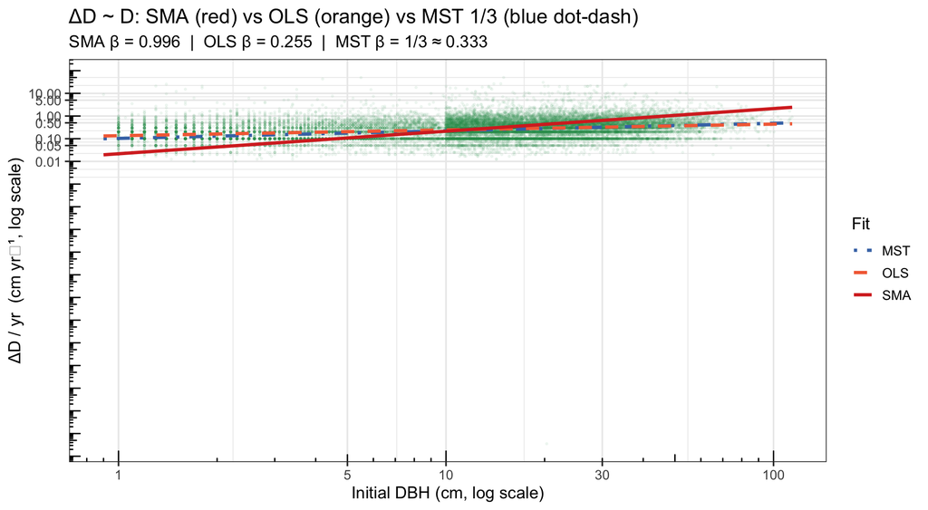

```r
# ── Purpose of this chunk ─────────────────────────────────────────────────────
# Scatter plot of ΔD vs D₀ with three fitted lines overlaid:
#   SMA (red solid)          — symmetric regression, best estimate of exponent
#   OLS (orange dashed)      — for comparison; expected to be below SMA
#   MST reference (blue dot-dash) — β = 1/3, anchored at the median point
#
# The MST reference line is not a regression line; it is a power law Y = α·X^(1/3)
# where α is chosen so the line passes through the median (DBH_start, DBH_inc).
# This anchoring strategy shows the shape of the theoretical prediction without
# imposing an intercept from a different dataset.

set.seed(42)  # reproducible subsample for scatter plot
sub <- pos_dbh |> sample_n(min(25000, n()))  # 25k points for legibility

# Generate fitted line values across the observed DBH range.
rng_D  <- range(sub$log_D0)
xs_D   <- seq(rng_D[1], rng_D[2], length.out = 200)
cf_dD  <- fit_sma_dD$coef[[1]]  # reuse fit from global SMA chunk
# SMA fitted line: log(ŷ) = intercept + slope × log(x)
# Back-transform to original scale for plotting with scale_x_log10.
ys_sma <- cf_dD["elevation","coef(SMA)"] + cf_dD["slope","coef(SMA)"] * xs_D
ys_ols <- coef(fit_ols_dD)[1] + coef(fit_ols_dD)[2] * xs_D

# MST reference: anchored at the bivariate median of the full dataset
# (not the subsample) so the reference line position is stable.
med_D     <- median(pos_dbh$DBH_start)    # median initial DBH (cm)
med_dD    <- median(pos_dbh$DBH_inc_cm_yr)  # median annual increment (cm/yr)
alpha_mst <- med_dD / med_D^(1/3)  # prefactor α: ensures MST line passes through median

lines_df <- data.frame(
  DBH_cm = exp(xs_D),
  SMA    = exp(ys_sma),
  OLS    = exp(ys_ols),
  MST    = alpha_mst * exp(xs_D)^(1/3)  # MST theoretical: ΔD ~ D^(1/3)
) |> pivot_longer(-DBH_cm, names_to = "fit", values_to = "dD")

ggplot(sub, aes(x = DBH_start, y = DBH_inc_cm_yr)) +
  geom_point(alpha = 0.06, size = 0.5, color = "#1a9850") +
  geom_line(data = lines_df,
            aes(x = DBH_cm, y = dD, color = fit, linetype = fit),
            linewidth = 1.2, inherit.aes = FALSE) +
  scale_color_manual(values  = c(SMA = "#d73027", OLS = "#f46d43",
                                  MST = "#4575b4"), name = "Fit") +
  scale_linetype_manual(values = c(SMA = "solid", OLS = "dashed",
                                    MST = "dotdash"), name = "Fit") +
  scale_x_log10(labels = comma, breaks = c(1, 5, 10, 30, 100)) +
  scale_y_log10(labels = comma,
                breaks = c(0.01, 0.05, 0.1, 0.5, 1, 5, 10)) +
  annotation_logticks() +
  labs(
    x = "Initial DBH (cm, log scale)",
    y = "\u0394D / yr  (cm yr\u207b\u00b9, log scale)",
    title = "\u0394D ~ D: SMA (red) vs OLS (orange) vs MST 1/3 (blue dot-dash)",
    subtitle = paste0(
      "SMA \u03b2 = ", round(cf_dD["slope","coef(SMA)"], 3),
      "  |  OLS \u03b2 = ", round(coef(fit_ols_dD)[2], 3),
      "  |  MST \u03b2 = 1/3 \u2248 0.333"
    )
  )
```

## 3.3 Binned means: SMA vs OLS vs MST

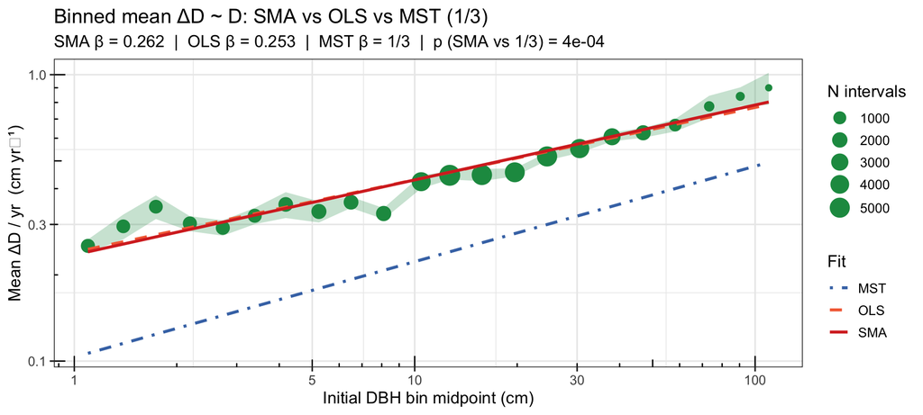

```r
# ── Purpose of this chunk ─────────────────────────────────────────────────────
# Reduce noise from individual-level variation by binning initial DBH on a
# log scale and fitting SMA to the 24 bin means. This is a robustness check:
# if the individual-level and binned slopes agree, the result is not artefact
# of high individual-to-individual variance dominating the regression.
#
# Binning strategy: 24 equal-width intervals on log scale from log(1) to log(200).
# Each bin summarises mean(ΔD) ± SE. Bins with fewer than 10 intervals excluded.
# alpha_mst is computed in the scatter chunk and is reused here (same reference).
bin_dbh <- pos_dbh |>
  mutate(DBH_bin = cut(log_D0,
                       breaks = seq(log(1), log(200), length.out = 25),
                       include.lowest = TRUE)) |>
  filter(!is.na(DBH_bin)) |>
  group_by(DBH_bin) |>
  summarise(n = n(), DBH_mid = exp(mean(log_D0)),  # geometric midpoint of bin
            mean_inc = mean(DBH_inc_cm_yr),
            se_inc   = sd(DBH_inc_cm_yr) / sqrt(n()),  # standard error (not SD)
            .groups = "drop") |>
  filter(n >= 10) |>   # require at least 10 intervals per bin for stability
  mutate(log_D0 = log(DBH_mid), log_dD = log(mean_inc))

# SMA on bin means: same API as individual-level fit above.
fit_sma_bin <- sma(log_dD ~ log_D0, data = bin_dbh, method = "SMA",
                   slope.test = 1/3)
fit_ols_bin <- lm(log_dD ~ log_D0, data = bin_dbh)

cf_bin <- fit_sma_bin$coef[[1]]
rng_b  <- range(bin_dbh$log_D0)
xs_b   <- seq(rng_b[1], rng_b[2], length.out = 150)
lines_bin <- data.frame(
  DBH_mid  = exp(xs_b),
  SMA      = exp(cf_bin["elevation","coef(SMA)"] + cf_bin["slope","coef(SMA)"] * xs_b),
  OLS      = exp(coef(fit_ols_bin)[1] + coef(fit_ols_bin)[2] * xs_b),
  MST      = alpha_mst * exp(xs_b)^(1/3)  # same reference prefactor from scatter chunk
) |> pivot_longer(-DBH_mid, names_to = "fit", values_to = "mean_inc")

ggplot(bin_dbh, aes(x = DBH_mid, y = mean_inc)) +
  # ribbon shows ±SE around bin mean (grey band)
  geom_ribbon(aes(ymin = pmax(mean_inc - se_inc, 1e-4),
                  ymax = mean_inc + se_inc),
              fill = "#1a9850", alpha = 0.25) +
  # point size proportional to number of intervals in bin (reader can see weight)
  geom_point(aes(size = n), color = "#1a9850") +
  geom_line(data = lines_bin,
            aes(x = DBH_mid, y = mean_inc, color = fit, linetype = fit),
            linewidth = 1.1, inherit.aes = FALSE) +
  scale_color_manual(values  = c(SMA = "#d73027", OLS = "#f46d43",
                                  MST = "#4575b4"), name = "Fit") +
  scale_linetype_manual(values = c(SMA = "solid", OLS = "dashed",
                                    MST = "dotdash"), name = "Fit") +
  scale_x_log10(labels = comma, breaks = c(1, 5, 10, 30, 100)) +
  scale_y_log10(labels = comma) +
  annotation_logticks() +
  scale_size_continuous(range = c(2, 7), name = "N intervals") +
  labs(
    x = "Initial DBH bin midpoint (cm)",
    y = "Mean \u0394D / yr  (cm yr\u207b\u00b9)",
    title = "Binned mean \u0394D ~ D: SMA vs OLS vs MST (1/3)",
    subtitle = paste0(
      "SMA \u03b2 = ", round(cf_bin["slope","coef(SMA)"], 3),
      "  |  OLS \u03b2 = ", round(coef(fit_ols_bin)[2], 3),
      "  |  MST \u03b2 = 1/3  |  p (SMA vs 1/3) = ",
      round(fit_sma_bin$slopetest[[1]]$p, 4)
    )
  )
```

# 4 $\Delta M \sim M^{\gamma}$: SMA vs OLS

> AGB is model-derived from DBH — slopes here primarily reflect the Chojnacky allometric equations embedded in NEON data processing.

```r
# ── Purpose of this chunk ─────────────────────────────────────────────────────
# Fit global SMA and OLS for log(ΔAGB) ~ log(AGB) and test slope vs β = 3/4.
#
# MST/WBE metabolic scaling predicts that biomass growth rate (dM/dt) ∝ M^(3/4),
# which means the log-log exponent should be 3/4 ≈ 0.75 (Enquist et al. 1999).
#
# ⚠️  CRITICAL CAVEAT: In NEON, AGBChojnacky is computed from DBH via species-
# specific allometric equations (Chojnacky et al. 2014). This means ΔAGB and
# AGB are NOT independent variables — both are deterministic functions of DBH
# measurements. Any slope in this regression partially reflects the mathematical
# structure of the allometric equations, not empirical mass measurements. The
# exponent should be interpreted with this constraint in mind.
fit_sma_dM <- sma(log_dM ~ log_M0, data = pos_agb, method = "SMA",
                  slope.test = 3/4)    # test H₀: β = 3/4 (MST metabolic scaling)
fit_ols_dM <- lm(log_dM ~ log_M0, data = pos_agb)

cf_dM <- fit_sma_dM$coef[[1]]  # smatr coef matrix: rows "elevation","slope"

kable(data.frame(
  Method   = c("SMA", "OLS"),
  N        = format(nrow(pos_agb), big.mark=","),
  slope    = c(round(cf_dM["slope","coef(SMA)"], 4),
               round(coef(fit_ols_dM)[2], 4)),
  CI_lo    = c(round(cf_dM["slope","lower limit"], 4), NA),
  CI_hi    = c(round(cf_dM["slope","upper limit"], 4), NA),
  R2       = round(summary(fit_ols_dM)$r.squared, 3),
  p_vs_3_4 = c(round(fit_sma_dM$slopetest[[1]]$p, 6), NA),  # H₀: β = 3/4
  stringsAsFactors = FALSE
),
col.names = c("Method","N","Slope","95% CI lo","95% CI hi","R\u00b2",
              "p (vs 3/4)"),
caption = paste0(
  "Global SMA and OLS log-log \u0394AGB ~ AGB\u1da7 exponents. ",
  "MST prediction: \u03b3 = 3/4. ",
  "\u26a0 AGB is derived from DBH (not independent)."
))
```

Global SMA and OLS log-log ΔAGB ~ AGBᶧ exponents. MST prediction: γ = 3/4. ⚠ AGB is derived from DBH (not independent).

|  | Method | N | Slope | 95% CI lo | 95% CI hi | R² | p (vs 3/4) |
| --- | --- | --- | --- | --- | --- | --- | --- |
|  | SMA | 43,848 | 0.7981 | 0.7947 | 0.8015 | 0.791 | 0 |
| log_M0 | OLS | 43,848 | 0.7098 | NA | NA | 0.791 | NA |

## 4.1 $\Delta M$ scatter: SMA vs OLS vs MST

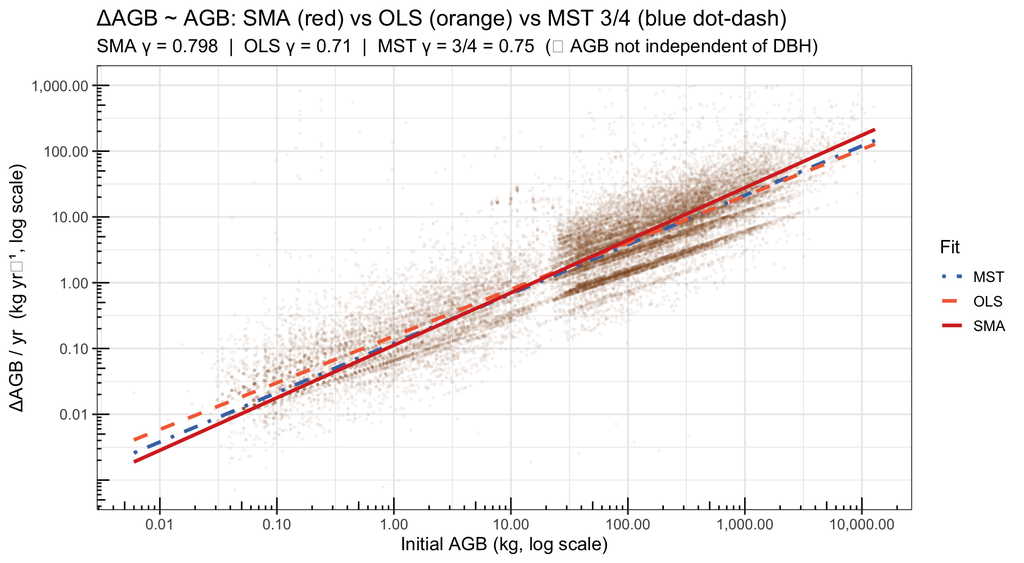

```r
# ── Purpose of this chunk ─────────────────────────────────────────────────────
# Scatter plot of ΔAGB vs AGB₀ analogous to the ΔD scatter chunk.
# Extreme outliers (AGB > 20,000 kg or increment > 1,000 kg/yr) are removed
# before subsampling; these are real but are likely data entry anomalies or
# very large trees that would compress the visual axis scale.
# The MST reference is anchored at the median of the unfiltered pos_agb data.
set.seed(42)
sub_agb <- pos_agb |>
  filter(AGB_start < 20000, AGB_inc_kg_yr < 1000) |>  # trim extreme outliers for plot
  sample_n(min(25000, n()))  # subsample for rendering speed

rng_M    <- range(sub_agb$log_M0)
xs_M     <- seq(rng_M[1], rng_M[2], length.out = 200)
ys_sma_M <- cf_dM["elevation","coef(SMA)"] + cf_dM["slope","coef(SMA)"] * xs_M
ys_ols_M <- coef(fit_ols_dM)[1] + coef(fit_ols_dM)[2] * xs_M

# MST reference: anchor at the median of the full (unfiltered) pos_agb data
med_M         <- median(pos_agb$AGB_start)
med_dM        <- median(pos_agb$AGB_inc_kg_yr)
alpha_mst_agb <- med_dM / med_M^(3/4)  # prefactor so MST line passes through median

lines_agb <- data.frame(
  AGB_start = exp(xs_M),
  SMA       = exp(ys_sma_M),
  OLS       = exp(ys_ols_M),
  MST       = alpha_mst_agb * exp(xs_M)^(3/4)  # MST theoretical: ΔAGB ~ AGB^(3/4)
) |> pivot_longer(-AGB_start, names_to = "fit", values_to = "AGB_inc")

ggplot(sub_agb, aes(x = AGB_start, y = AGB_inc_kg_yr)) +
  geom_point(alpha = 0.05, size = 0.5, color = "#8c510a") +
  geom_line(data = lines_agb,
            aes(x = AGB_start, y = AGB_inc, color = fit, linetype = fit),
            linewidth = 1.2, inherit.aes = FALSE) +
  scale_color_manual(values  = c(SMA = "#d73027", OLS = "#f46d43",
                                  MST = "#4575b4"), name = "Fit") +
  scale_linetype_manual(values = c(SMA = "solid", OLS = "dashed",
                                    MST = "dotdash"), name = "Fit") +
  scale_x_log10(labels = comma,
                breaks = c(0.01, 0.1, 1, 10, 100, 1000, 10000)) +
  scale_y_log10(labels = comma,
                breaks = c(0.01, 0.1, 1, 10, 100, 1000)) +
  annotation_logticks() +
  labs(
    x = "Initial AGB (kg, log scale)",
    y = "\u0394AGB / yr  (kg yr\u207b\u00b9, log scale)",
    title = "\u0394AGB ~ AGB: SMA (red) vs OLS (orange) vs MST 3/4 (blue dot-dash)",
    subtitle = paste0(
      "SMA \u03b3 = ", round(cf_dM["slope","coef(SMA)"], 3),
      "  |  OLS \u03b3 = ", round(coef(fit_ols_dM)[2], 3),
      "  |  MST \u03b3 = 3/4 = 0.75  (\u26a0 AGB not independent of DBH)"
    )
  )
```

# 5 Per-site SMA exponents: $\Delta D \sim D$

```r
# ── Purpose of this chunk ─────────────────────────────────────────────────────
# Fit site-level SMA exponents for ΔD ~ D to test for geographic/ecological
# heterogeneity in the diameter growth scaling relationship. If MST is a
# universal physiological rule, all 23 sites should show β ≈ 1/3 regardless
# of climate, biome, or canopy structure.
#
# Minimum site sample = 50 positive intervals (n ≥ 50) for SMA stability.
# Sites that pass this filter are sorted by SMA slope (descending) in the table.
site_sma <- pos_dbh |>
  group_by(siteID) |>
  filter(n() >= 50) |>   # require ≥ 50 intervals per site for SMA stability
  group_split() |>
  lapply(function(d) {
    site    <- unique(d$siteID)
    # Site-level SMA fit with test against 1/3 — same API as global fit above
    fit_sma <- sma(log_dD ~ log_D0, data = d, method = "SMA",
                   slope.test = 1/3)
    fit_ols <- lm(log_dD ~ log_D0, data = d)
    cf      <- fit_sma$coef[[1]]
    data.frame(
      siteID    = site,
      n         = nrow(d),
      SMA_beta  = round(cf["slope","coef(SMA)"],  3),
      CI_lo     = round(cf["slope","lower limit"], 3),
      CI_hi     = round(cf["slope","upper limit"], 3),
      OLS_beta  = round(coef(fit_ols)[2], 3),
      R2        = round(summary(fit_ols)$r.squared, 3),
      p_vs_1_3  = round(fit_sma$slopetest[[1]]$p, 4),  # H₀: β = 1/3
      med_inc   = round(median(d$DBH_inc_cm_yr), 3),    # median annual increment (cm/yr)
      stringsAsFactors = FALSE
    )
  }) |> bind_rows() |> arrange(desc(SMA_beta))  # sort by slope to see range

kable(site_sma,
  col.names = c("Site","N","SMA \u03b2","CI lo","CI hi","OLS \u03b2",
                "R\u00b2","p (vs 1/3)","Median \u0394D"),
  caption = "Per-site SMA \u0394D ~ D exponents. MST prediction: \u03b2 = 1/3."
)
```

Per-site SMA ΔD ~ D exponents. MST prediction: β = 1/3.

|  | Site | N | SMA β | CI lo | CI hi | OLS β | R² | p (vs 1/3) | Median ΔD |
| --- | --- | --- | --- | --- | --- | --- | --- | --- | --- |
| log_D0…1 | GUAN | 1001 | 1.670 | 1.571 | 1.776 | 0.278 | 0.028 | 0 | 0.150 |
| log_D0…2 | ORNL | 2986 | 1.334 | 1.289 | 1.381 | 0.341 | 0.065 | 0 | 0.200 |
| log_D0…3 | TALL | 2097 | 1.217 | 1.168 | 1.269 | 0.277 | 0.052 | 0 | 0.300 |
| log_D0…4 | RMNP | 1610 | 1.189 | 1.133 | 1.249 | 0.136 | 0.013 | 0 | 0.200 |
| log_D0…5 | MLBS | 2688 | 1.168 | 1.125 | 1.212 | 0.180 | 0.024 | 0 | 0.200 |
| log_D0…6 | UKFS | 2531 | 1.161 | 1.118 | 1.206 | 0.237 | 0.042 | 0 | 0.350 |
| log_D0…7 | OSBS | 1616 | 1.149 | 1.095 | 1.206 | 0.096 | 0.007 | 0 | 0.350 |
| log_D0…8 | UNDE | 3234 | 1.067 | 1.033 | 1.103 | 0.327 | 0.094 | 0 | 0.250 |
| log_D0…9 | KONZ | 77 | 1.059 | 0.860 | 1.305 | 0.429 | 0.164 | 0 | 0.500 |
| log_D0…10 | DELA | 3422 | 0.991 | 0.961 | 1.022 | 0.378 | 0.146 | 0 | 0.300 |
| log_D0…11 | BLAN | 738 | 0.988 | 0.927 | 1.054 | 0.451 | 0.209 | 0 | 0.325 |
| log_D0…12 | GRSM | 2861 | 0.977 | 0.943 | 1.013 | 0.195 | 0.040 | 0 | 0.300 |
| log_D0…13 | STEI | 2974 | 0.968 | 0.935 | 1.001 | 0.302 | 0.097 | 0 | 0.300 |
| log_D0…14 | LENO | 1845 | 0.953 | 0.916 | 0.992 | 0.460 | 0.233 | 0 | 0.300 |
| log_D0…15 | CLBJ | 1291 | 0.950 | 0.902 | 1.001 | 0.262 | 0.076 | 0 | 0.400 |
| log_D0…16 | SCBI | 1596 | 0.947 | 0.905 | 0.991 | 0.371 | 0.153 | 0 | 0.300 |
| log_D0…17 | TREE | 3302 | 0.871 | 0.842 | 0.901 | 0.129 | 0.022 | 0 | 0.300 |
| log_D0…18 | SERC | 3338 | 0.842 | 0.817 | 0.869 | 0.350 | 0.172 | 0 | 0.200 |
| log_D0…19 | HARV | 5100 | 0.837 | 0.815 | 0.860 | 0.211 | 0.064 | 0 | 0.200 |
| log_D0…20 | BART | 5419 | 0.817 | 0.796 | 0.838 | 0.200 | 0.060 | 0 | 0.200 |
| log_D0…21 | JERC | 945 | 0.814 | 0.765 | 0.866 | 0.196 | 0.058 | 0 | 0.350 |
| log_D0…22 | YELL | 486 | 0.712 | 0.654 | 0.775 | 0.208 | 0.085 | 0 | 0.400 |